# My visual data story

# Stats 220 Project 4 – Fencing before and after

## Introduction

For my project 2, I observed the number of points I won vs lost in bouts of foil fencing on different days. Now, a few months later, we can look at the data and see what’s changed. Have I got better? Worse?

Some of the things I looked at last time were: - Average length of bouts on different days - Win ratio of bouts on different days - My confidence going into a bout.

## Adding ranking to the data

In order to judge the skill level of the crowd each day, I looked at my confidence going into the bout, as well as the win ratio for the bout. After project 2 finished, I realised that there’s a better option: the actual ranking of my opponent! Here’s a plot showing the average ranking of my opponents each day:

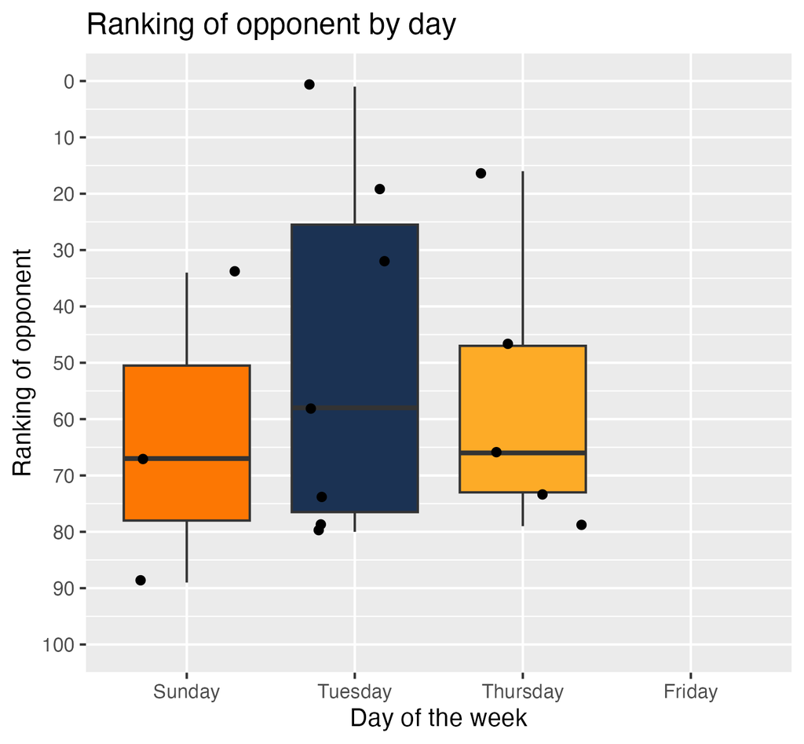

A plot showing the rankings of opponents by day

I also graphed my performance against ranking:

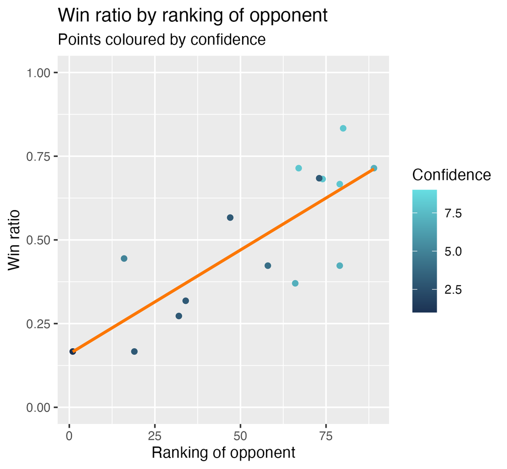

As you can see there’s a clear (and expected) trend: higher ranked opponents (with small numerical ranking) result in worse win ratios.

(I actually love this plot because I can look at the outliers and remember exactly what caused them.)

The other cool thing I can do with the ranking statistic is look at what rankings I fence the most. I made a density plot to show this:

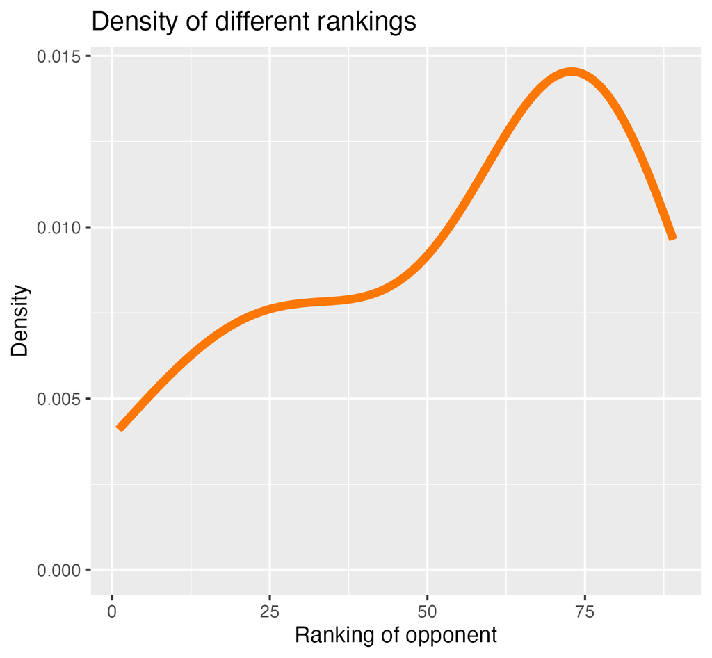

Finally, I coded something to see which fencers I’ve fenced the most often. (Using ranking as a sort of primary key since during this project everybody had a different ranking, though this isn’t suitable in the long term). During this project the person I fenced the most had rank 79, and this person is a friend of mine so it makes sense.

## Number of points per day

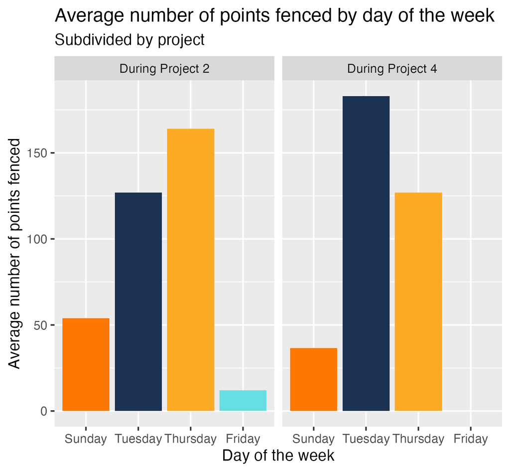

## Did I get better?

That’s the million dollar question: did I improve between the two projects. It’s a little hard to say definitively because I don’t have as much data for project 4 as I did for project 2, but here’s the graph:

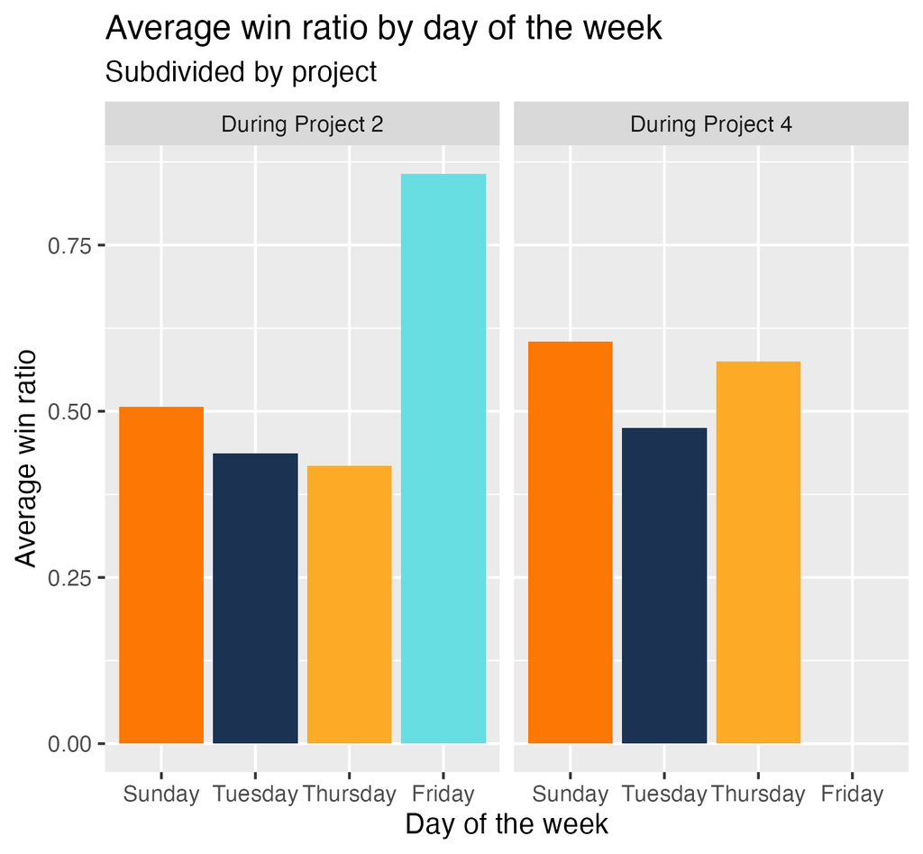

So that’s that! I look forward to throwing statistics at more of my hobbies in future.

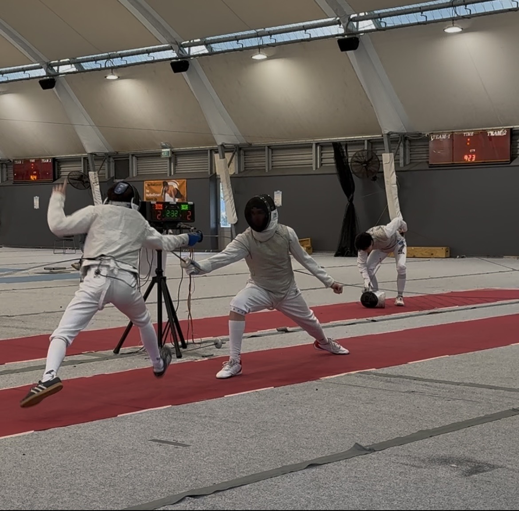

I, left, score a point against my friend from AUT